# Shiny App Development

Dr. Liu Qizhang

15 March 2019

## Introduction

This file covers the basics of Shiny app development.

## Overview

The R Shiny package has a simple yet powerful architecture, consisting of just two components, the User Interface (UI) and Server.

The UI is what users can see and interact with. Anything that the users do through the UI will be passed on as input to the Server.

The Server takes input from the UI and executes predefined logic as a response. The result is then passed back to the UI as output.

The UI then displays the output to users.

It is possible to run both the UI and Server on your local computer as a **standalone app** or host it on a **cloud server** so that it is available on the internet.

### Advantages

One advantage of Shiny is that code can be converted into HTML script, allowing us to directly embed it in an HTML page. For example, you could create your own e-commerce site with an R shiny app embedded in it.

## First Shiny App

We will build our first Shiny app to show Sentosa Island on the Singapore map. Our first leaflet map was also about Sentosa Island, and it provided a zoom in and zoom out button for us to control the map.

Now, we want our Shiny app to control the zoom level with a slider. The slider should have a default zoom level and when we slide the bar, the map will zoom accordingly.

Firstly, we will want to create a new R script in RStudio and save it as ‘app.R’ - the default name recognized by R as a Shiny app. It is important to use this name precisely. Otherwise, R will not know you are developing an app.

For **windows**, you can use the shortcut **CTRL + SHIFT + N** to create a new R script, then use the shortcut **CTRL + S** to save it as ‘app.R’.

For **mac**, you can use the shortcut **COMMAND + SHIFT + N** to create a new R script, then use the shortcut **COMMAND + S** to save it as ‘app.R’.

Let’s first make use of the default template Shiny code to start. This consists of three parts: **UI**, **Server** and **Shiny app**.

Copy and paste the following code into your ‘app.R’ file.

```r
library(shiny)

#Define UI for app
ui <- fluidPage()

#Define server logic
server <- function(input, output){}

shinyApp(ui=ui, server=server)
```

A typical UI consists of two parts: **controls** and **outputs**.

**Controls** are visual elements that allow users to interact with the system. For our first app, the slider is a control.

```r
ui <- fluidPage(
  sliderInput(inputId = "zoomlevel",
              label = "Map Zooming Level",
              value = 11,
              min = 1,
              max = 20)
)
```

This is done by inserting a line of code into UI. If we run our app.r file (you should notice it now has a ‘run app’ button where ‘run’ used to be in a normal R script), you should see

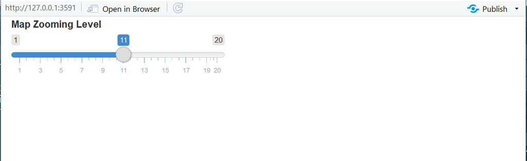

The title of the slider should be the label we set in our code. By default, the slider marker is set at 11, which is our value in the code. Additionally, the range of the slider is set by our min and max values.

Take note of the inputId, it is a unique identifier of the slider and its corresponding values. If you have tested sliding the bar, nothing will happen, because we haven’t defined the **outputs**.

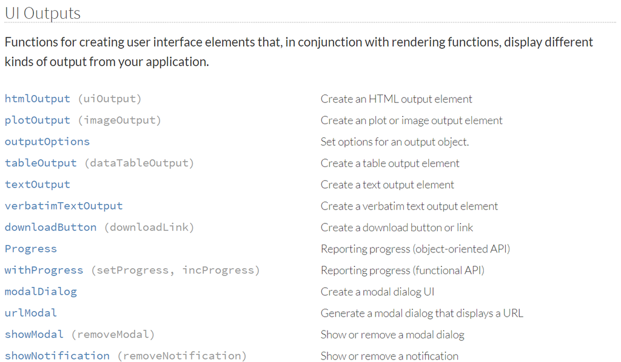

Shiny supports many different types of outputs as shown above, including, table, text, image, plot, map, etc. As we are going to show leaflet map, we will use *leafletOutput()*.

Our ui should now look like this:

```r
ui <- fluidPage(
  sliderInput(inputId = "zoomlevel",
              label = "Map Zooming Level",
              value = 11,
              min = 1,
              max = 20),  #Notice the added comma here
  leafletOutput(outputId = "plotMap")
)
```

We also need to give *leafletOutput()* a unique outputId. Whenever we make changes to a UI control, an event is triggered. The event passes the corresponding changes to the server, which has a listener reacting to the event to produce we would expect to say. In this case a new map with a changed zoom level.

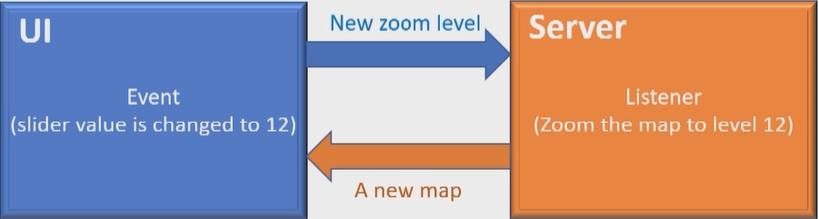

How the listener responses to events are coded in the server function. Let’s add the following code to it.

```r
server <- function(input, output){
  output$plotMap <- renderLeaflet(
    {
      leaflet() %>% setView(lng = 103.835381, lat = 1.239660,
                            zoom = input$zoomlevel) %>%
        addTiles() %>%
        addMarkers(lat = 1.239660, lng = 103.835381,
                   popup = "Sentosa Cove")
    }
  )
}
```

It defines what the output with id “plotMap” will look like. The output is generated by rendering a leaflet map. The code inside renderLeaflet is exactly the same as the previous lesson, except that zoom level is now set by the input with id “zoomlevel”.

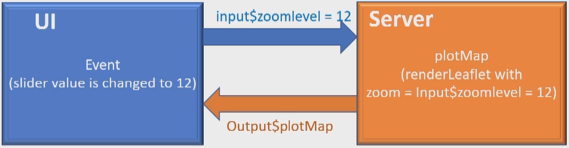

Let’s recap on how the app works. When the slider value changes to the number 12, input zoom level (“input$zoomlevel”) is set to 12. The Server function will render a leaflet with zoom level equal to the input zoom level (“input$zoomlevel”). The result is an output plot map (“output$plotMap”) that will be sent back to UI and displayed there.

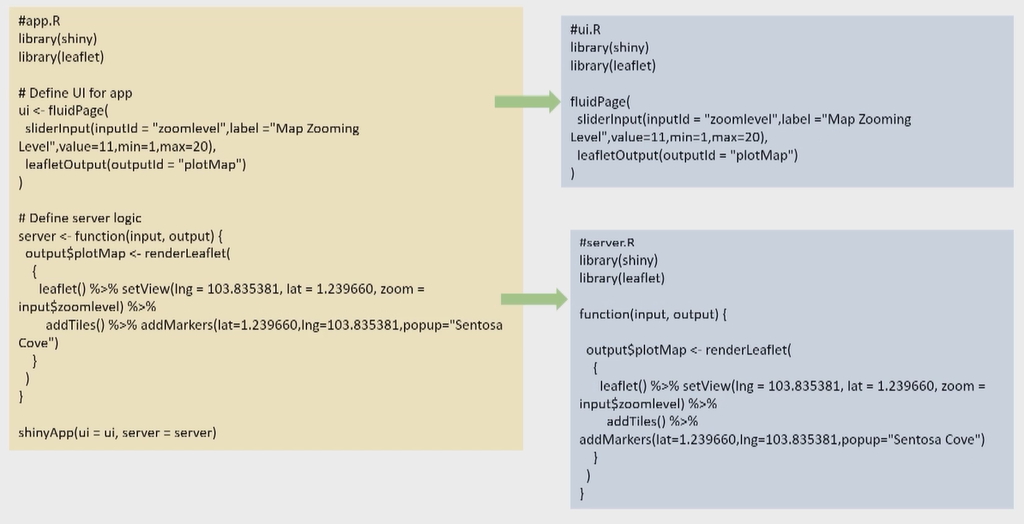

So far, we write everything is in ‘app.R’. However, it is possible to split it into two files, ‘ui.R’ and ‘server.R’ as above. These two files together will have the same effect as ‘app.R’.

Again, it is important to **save their file names exactly**.

In summary, to develop a Shiny app. We simply need to define two things. Define a UI control, and define an output model that links to the UI input. The most difficult part is the codes for rendering the desired output, which we have already covered previously.

## Shiny App Layout

The core of a Shiny app is the server code, which determines what kind of services your app could provide. However, this doesn’t mean UI is not important.

Recently, User Experience (UX) has gained unprecedented attention in the software industry. Easy of use and a great looking and feeling UI is essential in acquiring and retaining users.

We can make use of the layout template offered in Shiny for a better UI structure, and look and feel.

Think back to the case about health insurance, we saw how the willingness of buying health insurance differed by marital status of customers. What if we wanted to see the impact of the other attributes of the customers, such as sex, housing type, etc on their choices of buying health insurance?

We may want to design an app where we can select different radio buttons for changing bar positioning and a drop-down menu to select a customer attribute.

We will use a **layout** called sidebar layout. It is one of the most popular layouts where controls are organized in a sidebar and a large main space is reserved for output display.

```r
ui <- pageWithSidebar(
  headerPanel(),

  sidebarPanel(),

  mainPanel()
)
```

It consists of three components, “headerPanel”, “sidebarPanel” and “mainPanel”, separated by commas.

**Header Panel** is for us to give the title of the app.

```r
ui <- pageWithSidebar(
  headerPanel("How are customers' choices on buying health
              insurance affected?"),

  sidebarPanel(),

  mainPanel()
)
```

**Sidebar panel** stores all the input controls. In this case, we provide two controls, “selectInput” and “radioButtons”. Each control must have a unique input ID, label and a list of choices.

```r
ui <- pageWithSidebar(
  headerPanel("How are customers' choices on buying health
              insurance affected?"),

  sidebarPanel(
    selectInput(inputId = "attribute",
                label = "Customer Attribute",
                choices = c("housing.type", "sex",
                            "is.employed", "marital.stat")),
    radioButtons(inputId = "position",
                 label = "Bar Positioning",
                 choices = c("stack", "dodge", "fill"))
  ),

  mainPanel()
)
```

**Main panel** simply produces an output with output id “custPlot”.

```r
ui <- pageWithSidebar(
  headerPanel("How are customers' choices on buying health
              insurance affected?"),

  sidebarPanel(
    selectInput(inputId = "attribute",
                label = "Customer Attribute",
                choices = c("housing.type", "sex",
                            "is.employed", "marital.stat")),
    radioButtons(inputId = "position",
                 label = "Bar Positioning",
                 choices = c("stack", "dodge", "fill"))
  ),

  mainPanel(
    plotOutput("custPlot")
  )
)
```

Note that we are going to plot a chart using ggplot2, therefore “plotOutput” function is used here.

Server side, we just need to render a ggplot with an output id linked to the outputId defined in UI.

```r
ui <- pageWithSidebar(
  headerPanel("How are customers' choices on buying health
              insurance affected?"),

  sidebarPanel(
    selectInput(inputId = "attribute",
                label = "Customer Attribute",
                choices = c("housing.type", "sex",
                            "is.employed", "marital.stat")),
    radioButtons(inputId = "position",
                 label = "Bar Positioning",
                 choices = c("stack", "dodge", "fill"))
  ),

  mainPanel(
    plotOutput("custPlot")
  )
)

server <- function(input, output){
  output$custPlot <- renderPlot(
    {
      ggplot(custdata) +
        geom_bar(aes_string(x=input$attribute, fill="health.ins"),
                 position=input$position)
    }
  )
}
```

Notice that we are using aes_string instead of aes here, an input attribute (“input$attribute”) is passed in as a string and aes will not recognize it as a column of the data frame.

To summarize, adopting a layout is just about putting various parts of Shiny app codes in different components of a given layout template. Shiny provides several [other layout templates](https://shiny.rstudio.com/articles/layout-guide.html)

## Deploy app on Cloud

Once signed up, the website will show a step-by-step guide on how to deploy your app.

First, install the package ‘rsconnect’. Then, load this package in RStudio.

```r
install.packages('rsconnect')
library(rsconnect)
```

Next, you need to authorize the rsconnect package with your shinyapps account.

```r
rsconnect::setAccountInfo(name='YOURACCOUNTNAMEHERE',
                          token='YOURPERSONALAPIKEYHERE',
                          secret='YOURSECRETKEYHERE')
```

Shinyapps.io has nicely provided a way to copy all this to your clipboard painlessly.

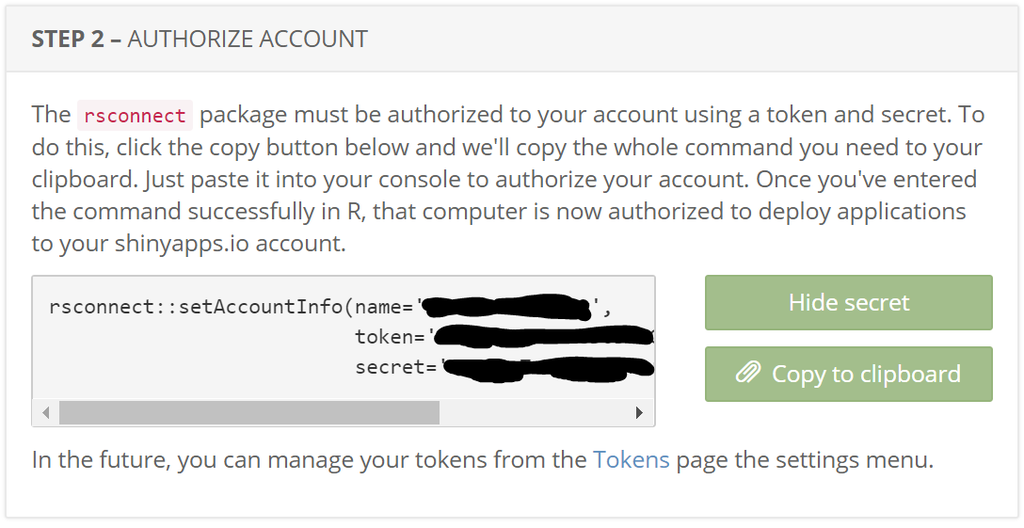

Remember to press the ‘Show secret’ button, before copying the code to your clipboard. Then run the command in your RStudio. As mentioned in the image above, once you log out, you can manage your tokens from Account > Tokens in the website.

Finally, to deploy your app, go to your RStudio and click on the button to the right of “Run App”. You will see a menu called “Publish Application”. Click on it.

In the popup screen:

[figure not shown]

You must save all the files needed in your app, such as image, data, text, etc. into one single folder, together with “app.R”. In the popup screen, select all the necessary files and then give a proper title to your app.

Then, click “Publish” to deploy it to the cloud server. Once the deployment is completed, a website will pop up in your web browser, showing your app. Record that URL in order to share it with others. You can also manage your apps in the website.